# Boundary Value Problem – Axial Temperature Variation of a current-carrying bare wire (problem 11.28 of the book Numerical Methods for Engineers and Scientists)

This notebook solves numerically the variation of the temperature of a current-carrying bare wire.

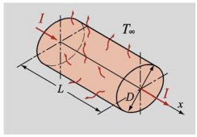

*Figure 1 – Axial Temperature Variation of a Current-Carrying Bare Wire*

The differential equation that describes the problem is the following:

$$\frac{d^2T}{dx^2} - \frac{4h}{kD}\,(T - T_\infty) - \frac{4 \varepsilon \sigma_{SB}}{kD}\,(T^4 - T_\infty^4) = -\frac{I^2 \rho_e}{k\,(\pi D^2 /4)^2}$$

**Boundary Conditions**:

- $T(0) = T_\infty$ ($x=0$)
- $\dfrac{dT}{dx}\big|_{x=L/2} = 0$ ($x=\frac{L}{2}$)

Notes:

- We are going to solve the boundary value problem for $0\leq x \leq \frac{L}{2}$.
- The solution is obtained with the help from a solver BVP from the python library `scipy.integrate.solve_bvp`

## 1. Import necessary libraries

Firstly we need to import necessary libraries to this notebook.

- `numpy` is needed for math operations such as numeric arrays, vectorized evaluation of the solution and parameters.
- `scipy` for the core boundary value problem solver bvp.
- `matplotlib` for plotting the results.

## 2. Physical Parameters

Below are the physical constants and parameters that define the problem.

These describe the thermal, electrical and geometric characteristics of the current-carrying wire.

## 3. Auxiliary Constants

To simplify the differential equation, we define some auxiliary constants below. These parameters remain constant trhoughout the domain and allow us to write the differential equation in a more compact form.

```
C1 = 1.458e+06, C2 = 4.134e-06, C3 = 8.548e+08
```

## 4. Define the Differential Equation and Boundary Conditions

### Second-Order ODE to First-Order System

We started from a second-order differential equation describing the steady-state temperature variation along the wire. $$ \frac{d^2T}{dx^2} - \frac{4h}{kD}(T - T_\infty) - \frac{4\varepsilon\sigma_{SB}}{kD}(T^4 - T_\infty^4) = -\frac{I^2 \rho_e}{k\left(\frac{\pi D^2}{4}\right)^2}. $$

To make it more suitable for numerical solution using `solve_bvp`, we converted this equation into a system of first-order equations by introducing two new variables:

$$ y_1(x) = T(x), \quad y_2(x) = \frac{dT}{dx}. $$

Substituting these definitions gives:

$$ \begin{cases} y_1' = y_2, \\[4pt] y_2' = C_1 (y_1 - T_\infty) + C_2 (y_1^4 - T_\infty^4) - C_3, \end{cases} $$

where the constants (C_1), (C_2), and (C_3) are defined as above.

### Boundary Conditions

Because the temperature distribution is symmetric about the midpoint of the wire, we only need to solve for half the wire length, from (x=0) to (x=L/2).

$$ \begin{cases} y_1(0) = T_\infty = 300\text{ K}, \\[4pt] y_2(L/2) = 0. \end{cases} $$

- The Dirichlet boundary condition fixes the temperature at the wire surface ($x=0$).
- The Neumann boundary condition imposes zero temperature gradient at the midpoint ($x=\frac{L}{2}$), representing symmetry and no heat flux through that plane.

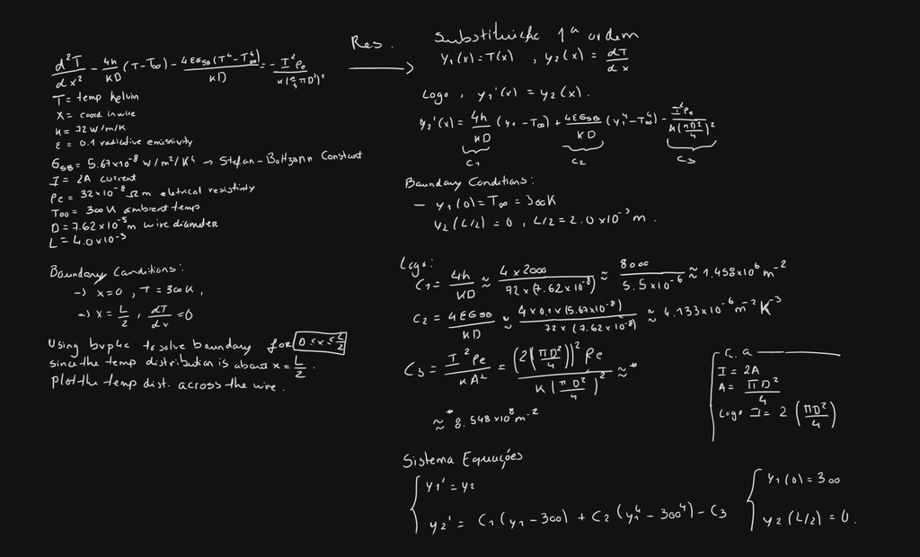

*Figure 2 – EDO Resolution*

## 5. Initial Guess

The boundary value solver requires an initial estimate for both the temperature $T(x)$ and its derivative $\frac{dT}{dx}$ along the domain.

As a physically reasonable starting point, we assume:

- The wire is initially at the ambient temperature $(T_\infty = 300\,\mathrm{K})$.
- There is no temperature gradient (flat profile).

This provides a simple and stable initial condition for the iterative solver: $$ T(x) = T_\infty, \quad \frac{dT}{dx} = 0. $$

## 6. BVP Solver

Similar to the MATLAB `bvp4c` function, we use the `solve_bvp` function from the `scipy.integrate` library to solve the boundary value problem numerically.

```
Solution converged.
```

```
T_max no centro (x=L/2): 781.60 K
```

## 8. Conclusion

The steady‑state axial temperature distribution of the current‑carrying bare wire was obtained by solving the boundary value problem on half the length (0 ≤ x ≤ L/2) using symmetry (T(0)=T∞ and dT/dx(L/2)=0).

The solution rises monotonically from the cooled end to a maximum at the center, where the axial heat flux vanishes. For the given parameters the computed centerline maximum temperature is T_max = 781.60 K.

Reformulating the second‑order ODE as a first‑order system enabled robust convergence with `solve_bvp`, yielding a smooth temperature field suitable for further parametric or interactive exploration.